# Item Reduction

Author

Riccardo Volpato

# Data Processing

```r
library(tidyverse)
library(gtools)
library(psych)
library(faux)
library(knitr)

set.seed(8675309) # makes sure random numbers are reproducible
```

```r
# read Qualtrics data without metadata rows
file_path <- "data/pilot/TPSai_11+March+2026_12.01.csv"
raw_data <- read_csv(file_path, n_max = 2)
colnames <- names(raw_data)
raw_data <- read_csv(file_path, col_names = colnames, skip = 3)
```

```r
# define variables for questions and answers
cols_trust    <- paste0("TR_", 1:23)
cols_distrust <- paste0("DT_", 1:13)
cols_company  <- paste0("CD_", 1:7)
cols_tpsai <- c(cols_trust, cols_distrust, cols_company)

likert_levels <- c(
  "Strongly disagree" = 1,
  "Disagree" = 2,
  "Neither agree nor disagree" = 3,
  "Agree" = 4,
  "Strongly agree" = 5,
  "Don't know" = NA
)
```

```r
# generate random data for code development before data collection
random_data <- as.data.frame(
  lapply(cols_tpsai, function(col) {
    sample(names(likert_levels), size=100, replace=TRUE)
  })
)
colnames(random_data) <- cols_tpsai
```

```r
analysis_data <- random_data # switch to raw_data after data collection

items_data <- analysis_data %>%
  select(all_of(cols_tpsai))  %>%
  mutate(across(all_of(cols_tpsai), ~ likert_levels[.x])) %>%
  # simulate one column with >.3 missingness
  faux::messy(prop = .4, "TR_1") %>%
  # make a high correlation between DISTRUST_1 and _2
  mutate(DT_2 = DT_1 + sample(-1:1, n(), replace = TRUE),
         DT_2 = case_match(DT_2, 0 ~ 1, 6 ~ 5, .default = DT_2))
```

# Item Evaluation

## High missingness

High missingness items, where many people respond “*Don’t know”*, likely capture constructs that participants are uncertain about and can reduce the effective sample size and bias item statistics like means and correlations. Given that we have a substantial number of survey itemsremoving high missingness items is a way of shortening our survey by focusing on constructs that people have clearer ideas about.

We decided to drop items exceeding 30% missing responses. Our rationale is that if at least 3 out of 10 individuals were not able to meaningfully engage with an item, dropping it simplifies our scale and allows it to focus on measuring items with generally clearer responses. 30% is a relatively moderate threshold for removal of items with high missingness, which might avoid premature dropping of items with moderate missingness may still yield interpretable results.

However, beyond just dropping items with at least 30% missingness, we want to inspect the distribution of missing answers per item, grouped by sub-scale. When visually inspecting this distribution we will look for discontinuities, meaning items with a substantially higher proportion of “Don’t know” than other items in the same sub-scale. We may remove such items even if below our pre-set missingness threshold.

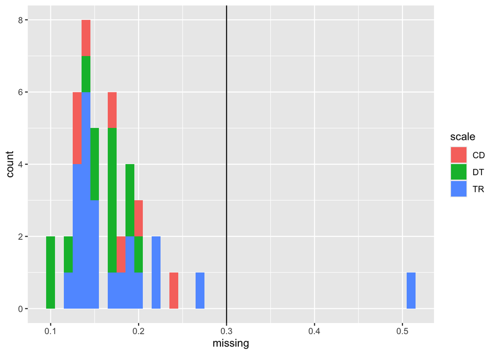

```r
missing_threshold <- 0.3

missing_items <- items_data %>%
  summarise(
    across(all_of(cols_tpsai), ~ mean(is.na(.x)), .names = "{.col}_missing")
  ) %>%
  pivot_longer(
    everything(),
    names_to  = c("item", ".value"),
    names_sep = "_(?=[^_]+$)"
  ) %>%
  separate(item, c("scale", "q_n"), sep = "_", remove = FALSE)

ggplot(missing_items, aes(x = missing, fill = scale)) +
  geom_histogram(binwidth = 0.01) +
  geom_vline(xintercept = missing_threshold)
```

```r
missing_items %>%
  filter(missing > missing_threshold) %>%  # add in other criteria from visual inspection
  select(item, missing) %>%
  knitr::kable(digits = 2)
```

| item | missing |
| --- | --- |
| TR_1 | 0.51 |

## **Distributional Properties**

We examine the skewness and kurtosis of each item to assess whether their distributions deviate substantially from normality. Skewness captures the asymmetry of a distribution — whether responses cluster toward one end of the scale — while kurtosis captures the heaviness of the tails relative to a normal distribution. Both matter for factor analysis because standard maximum likelihood (ML) estimation assumes multivariate normality: when individual items depart strongly from normality, ML can produce biased parameter estimates, inflated chi-square statistics, and distorted standard errors (Kline 2016).

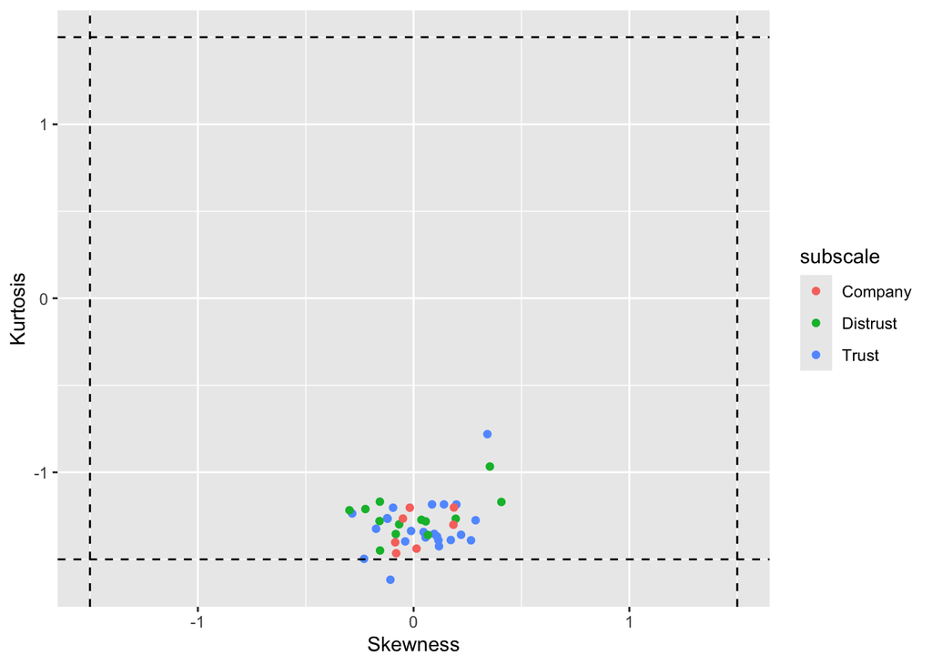

```r
dist_threshold <- 1.5

dist_data <- list(
  Trust    = cols_trust,
  Distrust = cols_distrust,
  Company  = cols_company
) %>%
  map_dfr(~ {
    items_data %>%
      select(all_of(.x)) %>%
      summarise(across(everything(), list(
        skew = ~ psych::skew(.x,    na.rm = TRUE),
        kurt = ~ psych::kurtosi(.x, na.rm = TRUE)
      ), .names = "{.col}__{.fn}")) %>%
      pivot_longer(everything(), names_to = c("item", "stat"), names_sep = "__") %>%
      pivot_wider(names_from = stat, values_from = value)
  }, .id = "subscale")


ggplot(dist_data, aes(x = skew, y = kurt, colour = subscale, label = item)) +
  geom_point() +
  geom_hline(yintercept = c(-dist_threshold, dist_threshold), linetype = "dashed") +
  geom_vline(xintercept = c(-dist_threshold, dist_threshold), linetype = "dashed") +
  labs(x = "Skewness", y = "Kurtosis")
```

```r
dist_data %>%
  filter(abs(skew) > dist_threshold | abs(kurt) > dist_threshold) %>%
  knitr::kable(digits = 2)
```

| subscale | item | skew | kurt |
| --- | --- | --- | --- |
| Trust | TR_18 | -0.11 | -1.62 |

## Inter-item Correlations

Next, we examine pairwise Polychoric inter-item correlations within each TPSai sub-scale (Trust, Distrust, and AI Company) to identify redundant items. Polychoric correlations are used as they are more appropriate for ordinal Likert-scale data than Pearson correlations Boateng et al. (2018). Items correlating above .80 with another item within the same sub-scale are considered redundant, as this indicates the two items share more than 64% of their variance (*r*² = .64), leaving little unique contribution to the scale.

As per our missingness check, we will also visually inspect inter-item correlations for any discontinuity in distribution across sub-scales, potentially identifying items worth merging even if correlated under our pre-set threshold.

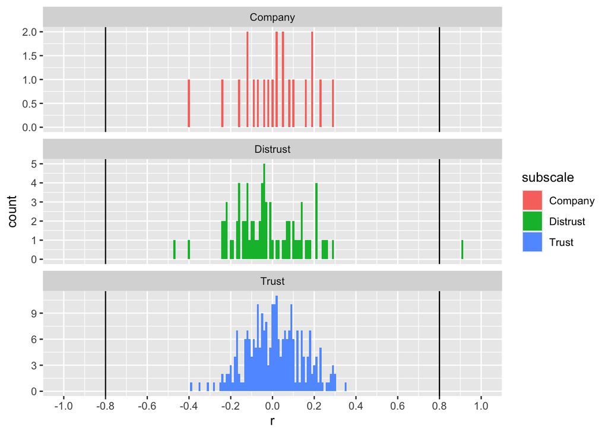

```r
ii_cor_threshold <- 0.8

ii_cor_data <- list(
  Trust = cols_trust,
  Distrust = cols_distrust,
  Company = cols_company
) %>%
  map_dfr(~ {
    items_data %>%
      select(all_of(.x)) %>%
      polychoric() %>%
      .$rho %>%
      as.data.frame() %>%
      rownames_to_column("item1") %>%
      pivot_longer(-item1, names_to = "item2", values_to = "r")
  }, .id = "subscale") %>%
  filter(r > -1 & r < 1) %>%
  filter(item1 < item2)

ii_cor_data %>%
  ggplot(aes(x = r, fill= subscale)) +
  facet_wrap(~subscale, ncol = 1, scales = "free_y") +
  geom_histogram(binwidth = 0.01) +
  geom_vline(xintercept = ii_cor_threshold) +
  geom_vline(xintercept = -ii_cor_threshold) +
  scale_x_continuous(breaks = seq(-1, 1, .2)) +
  coord_cartesian(xlim = c(-1, 1))
```

```r
ii_cor_data %>%
  filter(abs(r) > ii_cor_threshold) %>%
  select(subscale, item1, item2, r) %>% # add in other criteria from visual inspection
  knitr::kable(digits = 2)
```

| subscale | item1 | item2 | r |
| --- | --- | --- | --- |
| Distrust | DT_1 | DT_2 | 0.91 |

## Item-Total Correlations

As with previous checks, we will also visually inspect the distribution of item-total correlations within each sub-scale, looking for discontinuities that may identify items worth removing even if they fall above our pre-set threshold. Particular attention will be paid to any negatively correlating items, which would suggest an item is moving in the opposite direction to the rest of its sub-scale — a strong signal of potential issues with wording or construct alignment.

```r
it_cor_threshold <- 0.3

it_cor_data <- list(
  Trust    = cols_trust,
  Distrust = cols_distrust,
  Company  = cols_company
) %>%
  map_dfr(~ {
    items_data %>%
      select(all_of(.x)) %>%
      alpha() %>%
      .$item.stats %>%
      rownames_to_column("item") %>%
      select(item, r = r.drop)
  }, .id = "subscale")
```

```
Some items ( TR_1 TR_4 TR_5 TR_6 TR_15 TR_16 TR_17 TR_21 ) were negatively correlated with the first principal component and
probably should be reversed.
To do this, run the function again with the 'check.keys=TRUE' option
```

```
Some items ( DT_3 DT_6 DT_7 DT_9 DT_12 ) were negatively correlated with the first principal component and
probably should be reversed.
To do this, run the function again with the 'check.keys=TRUE' option
```

```
Some items ( CD_1 CD_4 CD_7 ) were negatively correlated with the first principal component and
probably should be reversed.
To do this, run the function again with the 'check.keys=TRUE' option
```

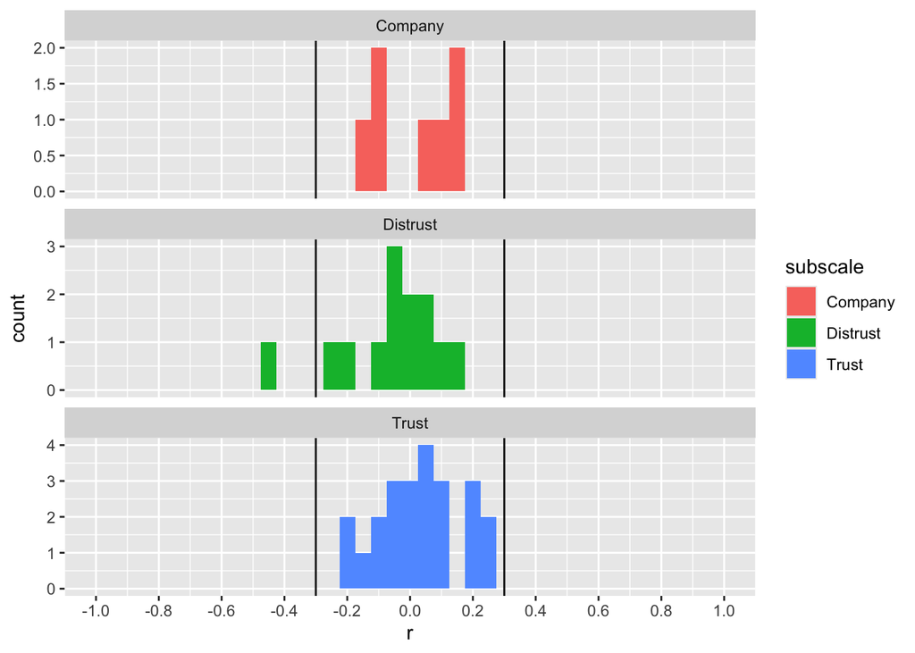

```r
it_cor_data %>%
  ggplot(aes(x = r, fill= subscale)) +
  facet_wrap(~subscale, ncol = 1, scales = "free_y") +
  geom_histogram(binwidth = 0.05) +
  geom_vline(xintercept = it_cor_threshold) +
  geom_vline(xintercept = -it_cor_threshold) +
  scale_x_continuous(breaks = seq(-1, 1, .2)) +
  coord_cartesian(xlim = c(-1, 1))
```

```r
it_cor_data %>%
  filter(abs(r) > it_cor_threshold) %>%
  select(item, r) %>% # add in other criteria from visual inspection
  knitr::kable(digits = 2)
```

| item | r |
| --- | --- |
| DT_7 | -0.44 |

## References

Boateng, Godfred O., Torsten B. Neilands, Edward A. Frongillo, Hugo R. Melgar-Quiñonez, and Sera L. Young. 2018. “Best Practices for Developing and Validating Scales for Health, Social, and Behavioral Research: A Primer.” *Frontiers in Public Health* 6 (June). https://doi.org/10.3389/fpubh.2018.00149.

Kline, Rex B. 2016. *Principles and Practice of Structural Equation Modeling, 4th Ed*. Principles and Practice of Structural Equation Modeling, 4th Ed. New York, NY, US: The Guilford Press.